# Optimal control and parameter estimation on GPUs

Tutorial 1 simulated dynamics forward. This tutorial solves the **optimal control problem** associated with the same dynamics: choose the control so the system arrives where we want it, at least cost, as a nonlinear program.

ExaModels.jl turns the model into GPU-ready evaluation and derivatives; MadNLP.jl solves it. Every model is written out in full: formulating is what this tutorial teaches.

## Setup

On the CPU we solve with **Ipopt**, through `NLPModelsIpopt`, because Ipopt is the reference interior-point code in this field and is the baseline a CPU number should be measured against. On the GPU we use **MadNLP**. Both consume the same ExaModels model, and both report `objective`, `iter` and a status. The device comparison later is therefore a comparison of two solvers as well as two devices.

```julia
using CUDA, CUDSS, ExaModels, MadNLP, MadNLPGPU, NLPModelsIpopt
using Plots

# Vector output: plots stay sharp at any zoom, and the notebook stays
# readable when rendered to HTML.
gr(fmt = :svg)
```

```
Plots.GRBackend()
```

## A warm-up solve

**Run the next cell now, then keep listening.** The first interior-point solve on the GPU in a fresh session compiles the entire solver stack, which takes roughly two to three minutes. Tutorial 1 showed the small version of this effect. It is paid **once per session**, and the second solve takes a fraction of a second. The problem below is deliberately trivial. Its only job is to make the compiler do all of its work now, rather than in the middle of an exercise. Each *new* model structure later adds a few seconds of compilation on its first solve. That part is unavoidable, but it is seconds rather than minutes.

```julia
function warmup(backend)
    wc = ExaCore(; backend = backend)
    @add_var(wc, x, 100; start = 0.5)
    @add_obj(wc, (x[i] - 1.0)^2 for i = 1:100)
    @add_con(wc, x[i] + x[i+1] for i = 1:99; lcon = -10.0, ucon = 10.0)
    m = ExaModel(wc)
    return backend === nothing ? ipopt(m; max_iter = 600, print_level = 0).status :
                                 madnlp(m; max_iter = 600).status
end
(cpu = warmup(nothing), gpu = warmup(CUDABackend()))
```

[output not shown]

```
(cpu = :first_order, gpu = MadNLP.SOLVE_SUCCEEDED)
```

Those six lines are the whole ExaModels API: variables, objective, constraints, model.

## A first optimal control problem

The pendulum from tutorial 1, now with a motor at the pivot. Which torque `u(t)` swings it from hanging down (θ = 0) to upright (θ = π) with least effort? The torque is capped well below gravity, so the answer has to *pump* the swing.

[figure not shown]

**Direct transcription**, the *simultaneous approach* of the lecture, turns the optimal control problem into an NLP. Lay a uniform grid of `N` intervals over the horizon, make the states `θ, ω` and the control `u` at each grid point decision variables, and impose the dynamics as constraints linking neighbours, here with the trapezoidal rule:

$$ \begin{aligned} \min_{\theta, \omega, u}\quad & \sum_{i=0}^{N} u_i^2\, \Delta t \\ \text{s.t.}\quad & \theta_i - \theta_{i-1} - \tfrac{\Delta t}{2}(\omega_i + \omega_{i-1}) = 0, && i = 1, \dots, N, \\ & \omega_i - \omega_{i-1} - \tfrac{\Delta t}{2}\big(f(\theta_i,\omega_i,u_i) + f(\theta_{i-1},\omega_{i-1},u_{i-1})\big) = 0, && i = 1, \dots, N, \\ & -u_{\max} \le u_i \le u_{\max}, && i = 0, \dots, N, \\ & \theta_0 = 0,\quad \omega_0 = 0,\quad \theta_N = \pi,\quad \omega_N = 0, \\[2pt] & \text{where } f(\theta, \omega, u) = u - 9.81 \sin\theta - 0.1\, \omega . \end{aligned} $$

Each line is one pattern repeated over its index, and each becomes a single ExaModels generator: the two dynamics families are `N` copies of one expression, the bound is `N+1` copies of another, and only the four boundary conditions are one-offs.

What comes out is a **structured NLP**: large, sparse, block-banded, and above all repetitive, which is exactly what ExaModels is built to exploit. Every constraint is written as a *generator* over the time grid, the SIMD pattern from the lecture: one expression, `N` instances. ExaModels compiles that into a single GPU kernel, and differentiates it on the GPU as well. We wrap the model in a function taking a `backend` argument. That one argument is the whole difference between CPU and GPU below.

```julia
function swingup_model(N; T = 5.0, u_max = 4.0, backend = nothing)
    dt = T / N
    c = ExaCore(; backend = backend)
    @add_var(c, θ, 0:N; start = [π * i / N for i = 0:N])
    @add_var(c, ω, 0:N; start = fill(π / T, N + 1))
    @add_var(c, u, 0:N; lvar = -u_max, uvar = u_max, start = zeros(N + 1))

    @add_obj(c, u[i]^2 * dt for i = 0:N)

    @add_con(c, θ[i] - θ[i-1] - dt / 2 * (ω[i] + ω[i-1]) for i = 1:N)
    @add_con(c,
        ω[i] - ω[i-1] - dt / 2 * ((u[i] - 9.81 * sin(θ[i]) - 0.1 * ω[i]) +
                                  (u[i-1] - 9.81 * sin(θ[i-1]) - 0.1 * ω[i-1]))
        for i = 1:N)

    @add_con(c, θ[0])
    @add_con(c, ω[0])
    @add_con(c, θ[N] - π)
    @add_con(c, ω[N])

    return ExaModel(c)
end
```

```
swingup_model (generic function with 1 method)
```

Three formulation choices here are deliberate. The boundary conditions are constraints like any other. ExaModels constraints are equalities unless you pass `lcon`/`ucon`, and the torque limit went on the *variable* instead.

The initial guess is *dynamically consistent*: θ ramps to π and ω starts at the matching average rate π/T. This is optional. An interior-point method does not need a feasible starting point and copes perfectly well with an inconsistent one, so `start` could be left at zero throughout. Supplying a guess that roughly satisfies the dynamics simply gives the solver less distance to travel, which is worth doing when it costs one line.

Build it and solve on the CPU:

```julia
N = 1000
model_cpu = swingup_model(N)
result_cpu = ipopt(model_cpu; max_iter = 600)
result_cpu.status
```

```
This is Ipopt version 3.14.19, running with linear solver MUMPS 5.9.0.

Number of nonzeros in equality constraint Jacobian...:    10004
Number of nonzeros in inequality constraint Jacobian.:        0
Number of nonzeros in Lagrangian Hessian.............:     3001

Total number of variables............................:     3003
                     variables with only lower bounds:        0
                variables with lower and upper bounds:     1001
                     variables with only upper bounds:        0
Total number of equality constraints.................:     2004
Total number of inequality constraints...............:        0
        inequality constraints with only lower bounds:        0
   inequality constraints with lower and upper bounds:        0
        inequality constraints with only upper bounds:        0

iter    objective    inf_pr   inf_du lg(mu)  ||d||  lg(rg) alpha_du alpha_pr  ls
   0  0.0000000e+00 6.28e-01 0.00e+00  -1.0 0.00e+00    -  0.00e+00 0.00e+00   0
   1  1.9954762e+01 3.20e-01 8.93e+00  -1.0 8.08e+00    -  3.31e-01 4.90e-01h  1
   2  2.4592804e+01 2.39e-01 7.09e+00  -1.0 3.27e+00   0.0 6.31e-01 2.52e-01h  1
   3  2.7100993e+01 2.17e-01 8.10e+00  -1.0 5.13e+01  -0.5 4.29e-02 9.42e-02h  1
   4  3.1567053e+01 1.10e-01 4.17e+00  -1.0 1.47e+00  -0.1 1.00e+00 4.94e-01h  1
   5  3.6117812e+01 6.75e-03 3.21e+00  -1.0 1.51e+00  -0.5 8.26e-01 9.38e-01h  1
   6  3.5675558e+01 2.41e-03 2.22e+00  -1.0 3.00e+00  -1.0 5.70e-01 8.19e-01f  1
   7  3.5054851e+01 4.23e-03 1.80e+00  -1.0 7.65e+00  -1.5 3.01e-01 4.57e-01f  1
   8  3.2335780e+01 1.55e-04 1.14e-01  -1.0 1.30e+00  -1.1 1.00e+00 1.00e+00f  1
   9  3.1866412e+01 1.02e-03 3.02e-01  -1.7 1.99e+00    -  6.52e-01 1.00e+00f  1
iter    objective    inf_pr   inf_du lg(mu)  ||d||  lg(rg) alpha_du alpha_pr  ls
  10  3.1769836e+01 1.46e-03 3.42e-01  -1.7 3.25e+00    -  3.58e-01 8.60e-01F  1
  11  2.9577556e+01 1.77e-04 3.17e-02  -1.7 1.58e+00    -  1.00e+00 1.00e+00f  1
  12  2.9471746e+01 2.18e-04 2.75e-02  -2.5 2.15e+00    -  4.91e-01 2.50e-01f  3
  13  2.9151897e+01 5.71e-06 6.19e-03  -3.8 2.19e-01  -1.5 8.86e-01 1.00e+00f  1
  14  2.8992573e+01 6.48e-04 9.24e-03  -3.8 1.51e+00    -  4.96e-01 5.00e-01f  2
  15  2.8940885e+01 8.53e-04 1.16e-02  -3.8 1.11e+00    -  5.80e-01 5.00e-01f  2
  16  2.8870109e+01 7.85e-04 1.02e-02  -3.8 8.48e-01    -  6.63e-01 5.00e-01f  2
  17  2.8785724e+01 6.29e-04 7.91e-03  -3.8 6.52e-01    -  8.40e-01 5.00e-01h  2
  18  2.8783020e+01 6.14e-04 7.65e-03  -3.8 1.18e+00    -  5.55e-01 1.47e-01h  3
  19  2.8453879e+01 1.49e-06 6.01e-04  -3.8 6.16e-02  -2.0 1.00e+00 1.00e+00f  1
iter    objective    inf_pr   inf_du lg(mu)  ||d||  lg(rg) alpha_du alpha_pr  ls
  20  2.8437061e+01 1.74e-06 8.83e-05  -5.7 7.38e-02    -  8.88e-01 1.00e+00f  1
```

[output cut: 15 more lines]

```
Variable bound violation:   0.0000000000000000e+00    0.0000000000000000e+00
Complementarity.........:   6.9434847817759740e-09    6.9434847817759740e-09
Overall NLP error.......:   6.9434847817759740e-09    6.9434847817759740e-09


Number of objective function evaluations             = 52
Number of objective gradient evaluations             = 29
Number of equality constraint evaluations            = 52
Number of inequality constraint evaluations          = 0
Number of equality constraint Jacobian evaluations   = 29
Number of inequality constraint Jacobian evaluations = 0
Number of Lagrangian Hessian evaluations             = 28
Total seconds in IPOPT                               = 2.416

EXIT: Optimal Solution Found.
```

```
:first_order
```

Each row of the log is one interior-point iteration. `inf_pr` and `inf_du` are the primal and dual infeasibilities driving to zero, and `lg(mu)` is the barrier parameter being driven down. Convergence in a few dozen iterations on a 3000-variable nonconvex problem is what interior-point methods are good at.

```julia
(objective = result_cpu.objective, iterations = result_cpu.iter)
```

```
(objective = 28.433180175975917, iterations = 28)
```

The solution comes back through `solution`, addressed by the variable handles our model function returned:

```julia
t_grid = range(0, 5.0; length = N + 1)
θ_sol = Array(solution(result_cpu, model_cpu.refs.θ))
u_sol = Array(solution(result_cpu, model_cpu.refs.u))
```

```
1001-element Vector{Float64}:
  0.09532692795142414
  0.22191775043853534
  0.2844301221533846
  0.3469039862959328
  0.4093239990009578
  0.47167482193947524
  0.5339411260840587
  0.5961075954738733
  0.6581589309785607
  0.7200798540601324
  ⋮
 -0.151481343795315
 -0.15416120810705383
 -0.1568802325780955
 -0.15963910384311006
 -0.1624385186556306
 -0.1652791840640551
 -0.16816181759026022
 -0.171087147410873
 -0.08628028904561526
```

Animating the trajectory shows the maneuver directly. The left panel is the pendulum, drawn from the pivot, with θ = 0 hanging down and θ = π upright. The right panel is the torque, with a cursor at the current time:

```
[ Info: Saved animation to /tmp/jl_vQ7WRobgXE.gif
```

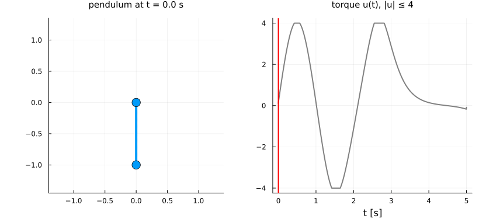

```julia
anim = @animate for k in 1:20:(N + 1)
    pend = plot([0, sin(θ_sol[k])], [0, -cos(θ_sol[k])];
        xlim = (-1.4, 1.4), ylim = (-1.45, 1.35), aspect_ratio = 1,
        lw = 4, marker = :circle, ms = 8, legend = false,
        titlefontsize = 10,
        title = "pendulum at t = $(round(t_grid[k]; digits = 2)) s")
    trace = plot(t_grid, u_sol;
        legend = false, lw = 2, color = :gray, titlefontsize = 10,
        xlabel = "t [s]", title = "torque u(t), |u| ≤ 4")
    vline!(trace, [t_grid[k]]; color = :red, lw = 2)
    plot(pend, trace; layout = (1, 2), size = (820, 380),
        left_margin = 4Plots.mm, bottom_margin = 4Plots.mm, top_margin = 3Plots.mm)
end
gif(anim, fps = 25)
```

The pumping is visible: the torque swings back and forth to build energy, then catches the pendulum at the top.

## The device switch

Everything above ran on the CPU. Here is the entire porting effort:

```julia
model_gpu = swingup_model(N; backend = CUDABackend())
result_gpu = madnlp(model_gpu; max_iter = 600, tol = 1e-8)
(status = result_gpu.status, objective = result_gpu.objective,
 cpu_objective = result_cpu.objective)
```

```
This is MadNLP version v0.10.1, running with cuDSS v0.8.0

Number of nonzeros in constraint Jacobian............:    10004
Number of nonzeros in Lagrangian Hessian.............:     3001

Total number of variables............................:     3003
                     variables with only lower bounds:        0
                variables with lower and upper bounds:     1001
                     variables with only upper bounds:        0
Total number of equality constraints.................:        0
Total number of inequality constraints...............:     2004
        inequality constraints with only lower bounds:        0
   inequality constraints with lower and upper bounds:     2004
        inequality constraints with only upper bounds:        0

iter    objective    inf_pr   inf_du inf_compl lg(mu) lg(rg) alpha_pr ir ls
   0  0.0000000e+00 6.28e-01 0.00e+00 4.00e+00  -1.0     -   0.00e+00  0  0
   1  3.2615633e-11 6.28e-01 4.97e-01 2.36e-03  -1.0     -   2.00e-07  1  2h
   2  1.9954762e+01 3.20e-01 2.38e-01 1.14e-03  -1.7     -   4.90e-01  2  1h
   3  2.5103522e+01 2.29e-01 2.34e-01 3.36e-04  -1.7    0.0  2.85e-01  1  1h
   4  2.9368662e+01 1.66e-01 2.98e-01 2.74e-04  -1.7   -0.5  2.76e-01  1  1h
   5  3.2207321e+01 1.03e-01 8.69e-02 1.31e-04  -1.7   -0.1  3.78e-01  1  1h
   6  3.5719699e+01 2.87e-02 7.12e-02 1.30e-04  -2.5   -0.5  7.21e-01  1  1h
   7  3.5791119e+01 1.09e-02 1.72e-01 1.22e-04  -2.5   -1.0  6.21e-01  1  1h
   8  3.5162404e+01 2.57e-03 2.69e-01 1.20e-04  -2.5   -1.5  1.00e+00  1  1h
   9  3.3546657e+01 1.77e-04 1.20e-01 6.98e-05  -2.5     -   1.00e+00  3  1h
iter    objective    inf_pr   inf_du inf_compl lg(mu) lg(rg) alpha_pr ir ls
  10  3.2923687e+01 7.20e-04 9.28e-02 5.24e-05  -2.5     -   1.00e+00  3  1h
  11  3.2099299e+01 1.29e-04 6.30e-02 3.67e-05  -2.5     -   1.00e+00  3  1h
  12  3.1543161e+01 2.71e-04 4.58e-02 2.74e-05  -2.5     -   1.00e+00  3  1h
  13  3.0998028e+01 3.66e-04 3.27e-02 2.15e-05  -2.5     -   1.00e+00  3  1h
  14  3.0495952e+01 5.15e-04 2.27e-02 1.61e-05  -2.5     -   1.00e+00  3  1h
  15  2.9898428e+01 3.78e-04 2.75e-02 1.75e-05  -3.8     -   1.00e+00  3  1h
  16  2.9511210e+01 4.06e-04 2.91e-02 1.80e-05  -3.8     -   1.00e+00  3  1h
  17  2.9250518e+01 5.43e-04 3.29e-02 1.80e-05  -3.8     -   1.00e+00  3  1h
  18  2.9047187e+01 6.03e-04 4.24e-02 1.73e-05  -3.8     -   1.00e+00  3  1h
  19  2.8896489e+01 6.08e-04 5.34e-02 1.57e-05  -3.8     -   1.00e+00  3  1h
iter    objective    inf_pr   inf_du inf_compl lg(mu) lg(rg) alpha_pr ir ls
  20  2.8780014e+01 5.51e-04 6.35e-02 1.34e-05  -3.8     -   1.00e+00  2  1h
  21  2.8680650e+01 4.35e-04 6.75e-02 1.04e-05  -3.8     -   1.00e+00  3  1h
```

[output cut: 22 more lines]

```
Number of objective function evaluations              = 34
Number of objective gradient evaluations              = 33
Number of constraint evaluations                      = 34
Number of constraint Jacobian evaluations             = 33
Number of Lagrangian Hessian evaluations              = 32
Number of KKT factorizations                          = 41
Number of KKT backsolves                              = 73

Total wall secs in initialization                     =  6.624 s
Total wall secs in linear solver                      =  unavailable
Total wall secs in NLP function evaluations           =  2.745 s
Total wall secs in solver (w/o init./fun./lin. alg.)  =  unavailable
Total wall secs                                       = 26.960 s

EXIT: Optimal Solution Found (tol = 1.0e-08).
```

```
(status = MadNLP.SOLVE_SUCCEEDED, objective = 28.432905769172695, cpu_objective = 28.433180175975917)
```

One argument moved evaluation, derivatives and the KKT factorizations to the GPU, and the two devices agree.

Note `tol = 1e-8`. MadNLP's GPU default is a loose `1e-4`, which suits the condensed-space method but not these problems. **Pass `tol = 1e-8` to every GPU solve.**

### (*) Scaling with problem size

> **Optional**

> A (*) marks material we may skip in the live session, depending on time. Nothing later depends on it, and the cells run on their own.

Grow the horizon and time both devices. Both columns are reported per iteration as well as in total, and the two tell different stories.

Both devices are warmed up before the loop, so compilation is not being timed. Everything that depends on the problem size, including model construction, is still inside the measurement.

```julia
# warm up both devices so the first row does not pay for compilation
ipopt(swingup_model(625); max_iter = 600, print_level = 0)
madnlp(swingup_model(625; backend = CUDABackend()); max_iter = 600, tol = 1e-8,
       print_level = MadNLP.ERROR)

sizes = [1_250, 2_500, 5_000, 10_000, 20_000]
times = map(sizes) do n
    m_c = swingup_model(n)
    t_c = @elapsed r_c = ipopt(m_c; max_iter = 600, print_level = 0)
    m_g = swingup_model(n; backend = CUDABackend())
    t_g = @elapsed r_g = madnlp(m_g; max_iter = 600, tol = 1e-8,
                                print_level = MadNLP.ERROR)
    (N = n, cpu_s = round(t_c; digits = 2), cpu_iters = r_c.iter,
     gpu_s = round(t_g; digits = 2), gpu_iters = r_g.iter,
     speedup = round(t_c / t_g; digits = 1),
     per_iter = round((t_c / r_c.iter) / (t_g / r_g.iter); digits = 1))
end
times
```

```
5-element Vector{@NamedTuple{N::Int64, cpu_s::Float64, cpu_iters::Int64, gpu_s::Float64, gpu_iters::Int64, speedup::Float64, per_iter::Float64}}:
 (N = 1250, cpu_s = 0.29, cpu_iters = 26, gpu_s = 0.28, gpu_iters = 35, speedup = 1.0, per_iter = 1.4)
 (N = 2500, cpu_s = 0.67, cpu_iters = 25, gpu_s = 0.23, gpu_iters = 27, speedup = 2.9, per_iter = 3.2)
 (N = 5000, cpu_s = 1.97, cpu_iters = 30, gpu_s = 0.28, gpu_iters = 30, speedup = 7.1, per_iter = 7.1)
 (N = 10000, cpu_s = 3.34, cpu_iters = 28, gpu_s = 0.48, gpu_iters = 33, speedup = 6.9, per_iter = 8.1)
 (N = 20000, cpu_s = 43.9, cpu_iters = 110, gpu_s = 0.4, gpu_iters = 31, speedup = 110.0, per_iter = 31.0)
```

The same numbers as a curve, with the break-even line marked:

```julia
plot([t.N for t in times], [t.speedup for t in times];
    xscale = :log10, marker = :circle, lw = 2, label = "total time")
plot!([t.N for t in times], [t.per_iter for t in times];
    marker = :square, lw = 2, ls = :dash, label = "per iteration",
    xlabel = "N (horizon length)", ylabel = "CPU / GPU",
    title = "GPU speedup against problem size")
hline!([1.0]; ls = :dot, color = :black, label = "break even")
```

[figure not shown]

The CPU side is what stops the table here. Past this point Ipopt takes minutes while the GPU is still under a second, so we grow the problem on the GPU alone:

```julia
for n in (40_000, 80_000, 160_000)
    m = swingup_model(n; backend = CUDABackend())
    t = @elapsed r = madnlp(m; max_iter = 600, tol = 1e-8,
                            print_level = MadNLP.ERROR)
    println(rpad("N = $n", 14), rpad("$(round(t; digits = 2)) s", 10),
            rpad("$(r.iter) iters", 12), r.status)
end
```

```
N = 40000     0.9 s     37 iters    SOLVE_SUCCEEDED
N = 80000     0.82 s    36 iters    SOLVE_SUCCEEDED
N = 160000    5.69 s    134 iters   SOLVE_SUCCEEDED
```

The iteration count holds near thirty-something out to 80,000 and then rises at 160,000, where the solve still finishes in a few seconds. That is the property worth noticing: the work inside an iteration parallelizes, so the time per iteration grows far more slowly than the problem does. How many iterations are needed is a question about the problem and the algorithm, not about the hardware, and it is the part a faster device cannot help with.

### ✏️ Exercise 1: minimum time

> **Your turn.** The horizon above was fixed at 5 seconds and we minimized control effort. Ask the opposite question: with a stronger motor, `u_max = 10`, what is the *fastest* swing-up?

> The final time has to become part of the problem. Goddard's rocket below does exactly this, so look at how it handles a free final time and apply the same idea here.

> Solve on the GPU, plot θ and u, and compare the torque with the minimum-effort solution.

Solution: [minimum-time-solution](https://madsuite.org/ifac2026/notebooks/minimum-time-solution.html).

## Goddard's rocket

Maximize the final altitude of a vertically launched rocket, with bounded thrust and drag that grows with speed. With altitude $h$, velocity $v$, mass $m$ and thrust $T$:

[figure not shown]

$$ \begin{aligned} \max_{T,\, t_f}\quad & h(t_f) \\ \text{s.t.}\quad & \dot h = v, \\ & \dot v = \frac{T - D(h, v) - m\, g(h)}{m}, \qquad \dot m = -\frac{T}{c}, \\ & D(h,v) = D_c\, v^2 \exp\!\big(-h_c (h - h_0)/h_0\big), \qquad g(h) = g_0 \left(\frac{h_0}{h}\right)^{2}, \\ & h(0) = h_0,\quad v(0) = 0,\quad m(0) = m_0,\quad m(t_f) = m_f, \\ & 0 \le T \le T_{\max}, \qquad h \ge h_0 . \end{aligned} $$

Two formulation ideas beyond the swing-up. The final time $t_f$ is *free*, so the step length becomes a decision variable, and we *maximize* by passing `minimize = false`.

The third idea is the transcription itself. Everything so far used the trapezoidal rule, which is second order: accuracy comes only from taking more steps. Here we use **orthogonal collocation on finite elements**, the method from Part II of the lecture, which transcribes at high order, stably for stiff systems, and purely algebraically.

Split the horizon into $N$ elements. On element $i$ of length $h_i$, with a local coordinate $\tau \in [0,1]$, represent each state as a degree-$K$ Lagrange polynomial through its values at $\tau_0 = 0 < \tau_1 < \dots < \tau_K$:

$$ z^K(t) = \sum_{j=0}^{K} \ell_j(\tau)\, z_{ij}, \qquad \ell_j(\tau) = \prod_{k \ne j} \frac{\tau - \tau_k}{\tau_j - \tau_k} . $$

Since $\ell_j(\tau_k) = \delta_{jk}$, the $z_{ij}$ *are* the state values at the nodes, and they are the decision variables. We cannot ask $\dot z^K = f(z^K, u)$ to hold at every $t$ with finitely many unknowns, so we impose it at the $K$ collocation points, which gives the **collocation equations**:

$$ \sum_{j=0}^{K} D_{kj}\, z_{ij} \;=\; h_i\, f\big(z_{ik},\, u_{ik}\big), \qquad i = 1, \dots, N, \quad k = 1, \dots, K, \qquad D_{kj} = \frac{d\ell_j}{d\tau}(\tau_k) . $$

Two indices this time, so the pattern repeats $N \times K$ times, and it is still one generator.

$D$ is a table of precomputed constants; the $z_{ij}$ and $h_i$ are the unknowns. Each equation is therefore a linear combination of unknowns set equal to $h_i f(\cdot)$, which is exactly the shape an NLP solver wants.

We use **Radau** points, whose last node sits at $\tau_K = 1$. That choice gives stiff decay and makes the continuity condition $z_{i+1,0} = \sum_j \ell_j(1) z_{ij}$ collapse to $z_{i+1,0} = z_{iK}$, since $\ell_j(1) = \delta_{jK}$: consecutive elements simply share the node.

$D$ follows from the nodes alone. Differentiating the Lagrange basis is one small linear solve:

```julia
# Radau IIA nodes for K = 3, giving order 2K-1 = 5 accuracy per element.
const RADAU_C = [0.15505102572168220, 0.64494897427831780, 1.0]

# D[k,j] = dl_j/dtau at tau_k, over the K+1 nodes [0, c...]. Obtained by
# writing the basis in monomials: values at the nodes are V, derivatives at
# the collocation points are Vp, so D = Vp / V.
function differentiation_matrix(c)
    K = length(c)
    τ = vcat(0.0, c)
    V = [τ[i]^(j - 1) for i = 1:K+1, j = 1:K+1]
    Vp = [(j - 1) * c[k]^(max(j - 2, 0)) * (j >= 2) for k = 1:K, j = 1:K+1]
    return Vp / V
end

D_RADAU = differentiation_matrix(RADAU_C)
```

```
3×4 Matrix{Float64}:
 -4.13939   3.22474   1.16784   -0.253197
  1.73939  -3.56784   0.775255   1.0532
 -3.0       5.53197  -7.53197    5.0
```

Worth a sanity check before trusting it: a constant state has zero derivative at every collocation point, and the state $z = \tau$ has derivative one.

```julia
(constant = D_RADAU * ones(4), linear = D_RADAU * vcat(0.0, RADAU_C))
```

```
(constant = [2.220446049250313e-16, 0.0, 0.0], linear = [1.0, 0.9999999999999999, 0.9999999999999999])
```

Now the model. Note what the decision variables are: the state at each element start, the state at each collocation point, one thrust per element, and the element length itself, since the final time is free.

```julia
function goddard_model(nh; K = 3, backend = nothing)
    c = RADAU_C
    D = differentiation_matrix(c)
    h_0, v_0, m_0, g_0 = 1.0, 0.0, 1.0, 1.0
    T_c, h_c, v_c, m_c = 3.5, 500.0, 620.0, 0.6
    cex = 0.5 * sqrt(g_0 * h_0)
    m_f = m_c * m_0
    D_c = 0.5 * v_c * (m_0 / g_0)
    T_max = T_c * m_0 * g_0

    core = ExaCore(; backend = backend, minimize = false)

    @add_var(core, step, 1; start = 1 / nh, lvar = 0.0)     # element length h_i
    # z_ij: state at node j of element i, with j = 0 the element start
    @add_var(core, h, 1:nh, 0:K; start = h_0, lvar = h_0)
    @add_var(core, v, 1:nh, 0:K; start = 0.1, lvar = v_0)
    @add_var(core, m, 1:nh, 0:K; start = m_0, lvar = m_f, uvar = m_0)
    @add_var(core, Th, 1:nh; start = T_max / 2, lvar = 0.0, uvar = T_max)

    @add_obj(core, h[nh, K])

    # One collocation row per (element, collocation point): the right-hand
    # side h_i f(z_ik), then the sum over j of D[k,j] z_ij added to it. Both
    # index rows through the same formula.
    pts = [(n = (i - 1) * K + k, i = i, k = k) for i = 1:nh for k = 1:K]
    trm = [(n = (i - 1) * K + k, i = i, j = j, d = D[k, j+1])
           for i = 1:nh for k = 1:K for j = 0:K]

    @add_con(core, ch, -step[1] * v[e.i, e.k] for e in pts)
    @add_con!(core, ch[e.n] += e.d * h[e.i, e.j] for e in trm)

    @add_con(core, cv, -step[1] *
        ((Th[e.i] - D_c * v[e.i, e.k]^2 * exp(-h_c * (h[e.i, e.k] - h_0) / h_0) -
          m[e.i, e.k] * g_0 * (h_0 / h[e.i, e.k])^2) / m[e.i, e.k]) for e in pts)
    @add_con!(core, cv[e.n] += e.d * v[e.i, e.j] for e in trm)

    @add_con(core, cm, step[1] * Th[e.i] / cex for e in pts)
    @add_con!(core, cm[e.n] += e.d * m[e.i, e.j] for e in trm)

    # continuity: the last node of an element is the first node of the next
    @add_con(core, h[i, K] - h[i+1, 0] for i = 1:nh-1)
    @add_con(core, v[i, K] - v[i+1, 0] for i = 1:nh-1)
    @add_con(core, m[i, K] - m[i+1, 0] for i = 1:nh-1)

    @add_con(core, h[1, 0] - h_0)
    @add_con(core, v[1, 0] - v_0)
    @add_con(core, m[1, 0] - m_0)
    @add_con(core, m[nh, K] - m_f)

    return ExaModel(core)
end
```

```
goddard_model (generic function with 1 method)
```

The published optimal final altitude for this problem is **1.01283** in normalized units (COPS 3.0), which gives us something independent to check the answer against:

```julia
# 200 intervals here, against the 1000 the trapezoidal swing-up needed:
# higher order buys accuracy that a finer grid would otherwise have to.
nh = 200
rocket = goddard_model(nh; backend = CUDABackend())
rocket_result = madnlp(rocket; max_iter = 600, tol = 1e-8)
(status = rocket_result.status, final_altitude = rocket_result.objective,
 published_optimum = 1.01283)
```

```
This is MadNLP version v0.10.1, running with cuDSS v0.8.0

Number of nonzeros in constraint Jacobian............:    13798
Number of nonzeros in Lagrangian Hessian.............:    13200

Total number of variables............................:     2601
                     variables with only lower bounds:     1601
                variables with lower and upper bounds:     1000
                     variables with only upper bounds:        0
Total number of equality constraints.................:        0
Total number of inequality constraints...............:     2401
        inequality constraints with only lower bounds:        0
   inequality constraints with lower and upper bounds:     2401
        inequality constraints with only upper bounds:        0

iter    objective    inf_pr   inf_du inf_compl lg(mu) lg(rg) alpha_pr ir ls
   0 -1.0100000e+00 3.96e-01 2.00e+00 1.75e+00  -1.0     -   0.00e+00  0  0
   1 -1.0100019e+00 3.96e-01 4.53e+01 3.76e-02  -1.0     -   3.98e-07  2  1h
   2 -1.0105262e+00 3.94e-01 5.15e+00 4.65e-03  -1.0     -   4.25e-03  2  1h
   3 -1.0144772e+00 3.83e-01 7.47e-01 9.26e-04  -1.0     -   2.95e-02  3  1h
   4 -1.0111270e+00 2.55e-01 8.04e+00 1.34e-03  -1.7     -   3.35e-01  3  1h
   5 -1.0161009e+00 2.19e-01 5.57e+00 1.00e-03  -1.7     -   1.40e-01  4  1h
   6 -1.0693253e+00 1.36e-01 7.48e+00 7.85e-04  -1.7     -   3.79e-01  6  1h
   7 -1.0538364e+00 8.77e-02 9.13e+00 5.84e-04  -1.7    2.0  3.55e-01  1  1h
   8 -1.0298894e+00 2.36e-02 4.69e+00 2.75e-04  -1.7    1.5  7.31e-01  1  1h
   9 -1.0217542e+00 1.81e-02 2.57e+00 1.30e-04  -1.7    1.0  2.30e-01  1  1h
iter    objective    inf_pr   inf_du inf_compl lg(mu) lg(rg) alpha_pr ir ls
  10 -1.0054530e+00 7.14e-03 2.35e+00 1.09e-04  -1.7    0.6  6.06e-01  1  1h
  11 -1.0066419e+00 7.93e-04 2.77e+00 6.20e-05  -1.7     -   9.89e-01  3  1h
  12 -1.0071486e+00 1.18e-04 7.39e+00 1.57e-05  -1.7     -   9.90e-01  3  1h
  13 -1.0087303e+00 5.87e-04 1.62e+01 6.03e-06  -1.7     -   1.00e+00  3  1h
  14 -1.0086710e+00 5.58e-05 1.16e-01 9.66e-06  -1.7     -   1.00e+00  2  1h
  15 -1.0086565e+00 8.46e-08 2.82e-02 6.27e-06  -2.5     -   1.00e+00  2  1h
  16 -1.0086572e+00 1.64e-09 9.09e-02 5.38e-06  -3.8     -   1.00e+00  2  1h
  17 -1.0086706e+00 5.30e-07 1.70e-04 3.56e-06  -3.8     -   1.00e+00  3  1h
  18 -1.0087672e+00 8.05e-07 3.02e+02 6.55e-06  -5.7     -   1.00e+00  2  1h
  19 -1.0098460e+00 1.42e-04 2.30e+02 5.00e-06  -5.7     -   1.00e+00  3  1h
iter    objective    inf_pr   inf_du inf_compl lg(mu) lg(rg) alpha_pr ir ls
  20 -1.0108674e+00 1.54e-04 5.08e+01 3.19e-06  -5.7     -   7.68e-01  3  1h
  21 -1.0117426e+00 1.51e-04 1.63e-01 4.71e-06  -5.7     -   1.00e+00  3  1h
```

[output cut: 21 more lines]

```
Number of objective function evaluations              = 32
Number of objective gradient evaluations              = 32
Number of constraint evaluations                      = 32
Number of constraint Jacobian evaluations             = 32
Number of Lagrangian Hessian evaluations              = 31
Number of KKT factorizations                          = 38
Number of KKT backsolves                              = 76

Total wall secs in initialization                     =  7.303 s
Total wall secs in linear solver                      =  unavailable
Total wall secs in NLP function evaluations           =  3.542 s
Total wall secs in solver (w/o init./fun./lin. alg.)  =  unavailable
Total wall secs                                       = 24.818 s

EXIT: Optimal Solution Found (tol = 1.0e-08).
```

```
(status = MadNLP.SOLVE_SUCCEEDED, final_altitude = 1.0128488516553145, published_optimum = 1.01283)
```

The altitude matches the literature. Checking optimizer output against something independent matters: `SOLVE_SUCCEEDED` means the algorithm met its own criterion, not that you modelled the right problem. And the trajectories:

```julia
h_traj = Array(solution(rocket_result, rocket.refs.h))[:, 1]   # node j=0 of each element
Th_traj = Array(solution(rocket_result, rocket.refs.Th))  # nh interval controls

p1 = plot(range(0, 1; length = nh), h_traj; lw = 2, legend = false,
    title = "Goddard: altitude")
p2 = plot(range(0, 1; length = nh), Th_traj; lw = 2, legend = false,
    title = "thrust (note the singular arc)", xlabel = "normalized time")
plot(p1, p2; layout = (2, 1), size = (760, 460),
    left_margin = 4Plots.mm, bottom_margin = 4Plots.mm)
```

[figure not shown]

The thrust profile has three phases: full burn, then a *singular arc*, a sustained intermediate thrust balancing drag against gravity, then cutoff.

## Particle steering

The **particle steering** problem (COPS calls it that; you will also see it as "rocket steering") is a minimum-time problem: steer a constant-magnitude thrust vector so a particle reaches a given height with a given terminal velocity as fast as possible. With position $(x_1, x_2)$, velocity $(x_3, x_4)$, steering angle $u$ and acceleration magnitude $a = 100$:

$$ \begin{aligned} \min_{u,\, t_f}\quad & t_f \\ \text{s.t.}\quad & \dot x_1 = x_3, \qquad \dot x_2 = x_4, \\ & \dot x_3 = a \cos u, \qquad \dot x_4 = a \sin u, \\ & x(0) = 0, \qquad x_2(t_f) = 5,\ x_3(t_f) = 45,\ x_4(t_f) = 0, \\ & -\tfrac{\pi}{2} \le u(t) \le \tfrac{\pi}{2} . \end{aligned} $$

Free final time again, here as an explicit `tf` variable that *is* the objective, with states in a 2-D matrix variable, indexed like an array.

A particle starts at rest at the origin. Its engine pushes with a fixed magnitude, and the only thing you choose is the *direction* of that push at each instant. The target is a state, not a place: be at height 5, travelling horizontally at 45, with no vertical motion left. Reach it as quickly as possible.

[figure not shown]

The arrows are the decision. Point them too steeply and the particle gains height quickly but arrives with vertical speed it must then cancel; point them too flat and it never reaches the height. The optimizer finds the schedule that trades these against each other in the least time.

> **Sources**

> Classical problem: A. E. Bryson and Y.-C. Ho, *Applied Optimal Control*, Wiley, 1975, pp. 59–62. The thrust magnitude and terminal conditions used here follow J. Betts, S. Eldersveld and W. Huffman, *Sparse nonlinear programming test problems (Release 1.0)*, Boeing Computer Services technical report BCSTECH-93-047, 1993, as collected in COPS 3.0 (problem 9): Dolan, Moré and Munson, ANL/MCS-TM-273, 2004.

### ✏️ Exercise 2: transcribe it yourself

> **Your turn.** You have the continuous-time statement above and nothing else. Transcribe it into an ExaModels model and solve it on the GPU with `tol = 1e-8`.

> **The discretization is your choice**: implicit Euler, the trapezoidal rule, or collocation. They differ in accuracy per grid point and in how many variables they cost, so the method you pick changes both the answer and the size of the problem.

> Report the status, the minimal flight time, and the iteration count. The published optimum is 0.55457; COPS reports 0.554577 at `nh` = 200 and 0.554571 at `nh` = 800, so the discretized optimum shifts slightly as the mesh is refined. Then plot the steering angle `u` over time and interpret what the rocket is doing.

```julia
# your code here
```

Solution: [particle-steering-solution](https://madsuite.org/ifac2026/notebooks/particle-steering-solution.html).

## Parameter estimation for dynamic models

> **Optional material**

> This section is extra material. We may not work through it live, depending on time. It is written to be read and run on your own afterwards, and nothing earlier in the workshop depends on it.

The problems above chose a control to reach a target. Estimation inverts the question: a system of ODEs carries unknown parameters, measurements of it are noisy, and the task is to find the parameters that best explain the data.

The machinery is the one you have already used. We discretize the dynamics into constraints as before, the states on the grid become decision variables as before, and the only changes are that the unknown parameters join the variable list and the objective measures misfit against data instead of control cost. This is the **simultaneous** (or "all-at-once") approach to dynamic optimization, and because it produces one large structured NLP, everything the GPU did for us above applies unchanged.

### The system

The JAK2/STAT5 signaling model of Boehm et al. (2014), a standard benchmark for parameter estimation.

[figure not shown]

STAT5 comes in two isoforms. A stimulus that decays over time phosphorylates them, they pair into three dimers, and those are imported into the nucleus and later exported back as monomers. Mass spectrometry measures the phosphorylated forms over four hours. The rate constants $k_{\text{phos}}$, $k_{\text{imp}}$, $k_{\text{exp}}$ and $k_{\text{deg}}$ are what we estimate.

For our purposes it is an 8-state nonlinear ODE with 9 unknown parameters and 48 noisy measurements: the shape of estimation problems in process control and systems biology alike.

> **Sources**

> Model and data: M. E. Boehm, L. Adlung, M. Schilling, S. Roth, U. Klingmüller and W. D. Lehmann, "Identification of Isoform-Specific Dynamics in Phosphorylation-Dependent STAT5 Dimerization by Quantitative Mass Spectrometry and Mathematical Modeling", *Journal of Proteome Research* 13(12):5685–5694, 2014 (doi:10.1021/pr5006923). Distributed as problem `Boehm_JProteomeRes2014` of the PEtab benchmark collection (H. Hass et al., "Benchmark problems for dynamic modeling of intracellular processes", *Bioinformatics* 35:3073–3082, 2019 doi:10.1093/bioinformatics/btz020), in the PEtab format of L. Schmiester et al., *PLOS Computational Biology* 17(1):e1008646, 2021 (doi:10.1371/journal.pcbi.1008646). We take the problem from that collection and write it out directly, as earlier in this tutorial.

### The dynamics

Eight species: cytosolic `STAT5A`, `STAT5B`, the three phosphorylated dimers `pApA`, `pApB`, `pBpB`, and their nuclear counterparts `nucpApA`, `nucpApB`, `nucpBpB`. Nine mass-action reactions, namely phosphorylation- driven dimerization (3), nuclear import (3) and nuclear export (3), with cytosolic and nuclear compartment volumes $V_c = 1.4$, $V_n = 0.45$:

$$ \begin{aligned} v_1 &= V_c\, E(t)\, k_{\text{phos}}\, \mathrm{STAT5A}^2, & v_4 &= V_c\, k_{\text{imp,homo}}\, \mathrm{pApA}, & v_7 &= V_n\, k_{\text{exp,homo}}\, \mathrm{nucpApA}, \\ v_2 &= V_c\, E(t)\, k_{\text{phos}}\, \mathrm{STAT5A}\,\mathrm{STAT5B}, & v_5 &= V_c\, k_{\text{imp,hetero}}\, \mathrm{pApB}, & v_8 &= V_n\, k_{\text{exp,hetero}}\, \mathrm{nucpApB}, \\ v_3 &= V_c\, E(t)\, k_{\text{phos}}\, \mathrm{STAT5B}^2, & v_6 &= V_c\, k_{\text{imp,homo}}\, \mathrm{pBpB}, & v_9 &= V_n\, k_{\text{exp,homo}}\, \mathrm{nucpBpB}, \end{aligned} $$

where the stimulus decays exponentially, $E(t) = 1.25\times10^{-7} \exp(-k_{\text{deg}}\, t)$. The balances (note the stoichiometric 2s: two monomers make one homodimer) are

$$ \begin{aligned} V_c\, \tfrac{d}{dt}\mathrm{STAT5A} &= -2v_1 - v_2 + 2v_7 + v_8, & V_c\, \tfrac{d}{dt}\mathrm{pApA} &= v_1 - v_4, & V_n\, \tfrac{d}{dt}\mathrm{nucpApA} &= v_4 - v_7, \\ V_c\, \tfrac{d}{dt}\mathrm{STAT5B} &= -2v_3 - v_2 + 2v_9 + v_8, & V_c\, \tfrac{d}{dt}\mathrm{pApB} &= v_2 - v_5, & V_n\, \tfrac{d}{dt}\mathrm{nucpApB} &= v_5 - v_8, \\ & & V_c\, \tfrac{d}{dt}\mathrm{pBpB} &= v_3 - v_6, & V_n\, \tfrac{d}{dt}\mathrm{nucpBpB} &= v_6 - v_9 . \end{aligned} $$

### What is measured

The instrument does not see the states. It sees three *relative* quantities the fraction of STAT5A that is phosphorylated, the same for STAT5B, and the relative amount of STAT5A overall. Each is a nonlinear function of the states involving a known isoform-specificity constant $c_{17} = 0.107$:

$$ \begin{aligned} y_1 &= \frac{100\,\mathrm{pApB} + 200\,\mathrm{pApA}\, c_{17}} {\mathrm{pApB} + \mathrm{STAT5A}\, c_{17} + 2\,\mathrm{pApA}\, c_{17}}, \\[2pt] y_2 &= \frac{-100\,\mathrm{pApB} + 200\,\mathrm{pBpB}\,(c_{17}-1)} {\mathrm{STAT5B}\,(c_{17}-1) - \mathrm{pApB} + 2\,\mathrm{pBpB}\,(c_{17}-1)}, \\[2pt] y_3 &= \frac{100\,\mathrm{pApB} + 100\,\mathrm{STAT5A}\, c_{17} + 200\,\mathrm{pApA}\, c_{17}} {2\,\mathrm{pApB} + \mathrm{STAT5A}\, c_{17} + 2\,\mathrm{pApA}\, c_{17} - \mathrm{STAT5B}\,(c_{17}-1) - 2\,\mathrm{pBpB}\,(c_{17}-1)} . \end{aligned} $$

Observation functions like these are the norm rather than the exception, because you almost never measure the state directly. Note they are *rational*, so the objective is not a least-squares problem in the standard sense but a nonconvex one.

The data, 16 time points from 0 to 240 minutes and three observables, ships next to this notebook as literal arrays:

```julia
include("boehm_data.jl")
(n_timepoints = length(T_DATA), t_final = T_DATA[end], n_measurements = 3 * length(T_DATA))
```

```
(n_timepoints = 16, t_final = 240.0, n_measurements = 48)
```

### Estimation as a nonlinear program

Three choices define it.

**The dynamics become constraints**, by the same orthogonal collocation used for Goddard. Nuclear import here is fast enough to make the system stiff, which rules out the trapezoidal rule: it is A-stable but not L-stable, so it rings on fast modes rather than damping them. Radau collocation damps them and is high order, so it costs nothing to prefer it. The elements are 2.5 minutes long, which puts every one of the 16 measurement times on an element boundary.

**The parameters become variables.** The rate constants span nine orders of magnitude, so we estimate $\theta = \log_{10} k$ and write $k = 10^{\theta}$ in the dynamics. Positivity is then automatic and the search space is well scaled.

**The objective is a likelihood.** With Gaussian noise of unknown standard deviation $\sigma_j$ per observable, dropping constants:

$$ \min_{\theta,\, \sigma,\, x(\cdot)} \quad \sum_{j=1}^{3} \sum_{i=1}^{16} \left[ \frac{\big(y_j(t_i) - \bar y_{j,i}\big)^2}{2\sigma_j^2} + \log \sigma_j \right] . $$

The $\log \sigma_j$ term stops the optimizer explaining the data by declaring the noise enormous. We estimate $\log_{10}\sigma$ for the same reason as the rate constants.

In ExaModels:

```julia
function boehm_model(N; K=3, backend=nothing)
    D = differentiation_matrix(RADAU_C)
    Vc, Vn = 1.4, 0.45; c17, ratio = 0.107, 0.693
    A0, B0 = 207.6*ratio, 207.6*(1-ratio)
    tf = T_DATA[end]; h = tf/N
    elem = [round(Int, t/h) for t in T_DATA]     # element index whose END is t (0 -> start)
    data = [PSTAT5A_REL, PSTAT5B_REL, RSTAT5A_REL]
    c = ExaCore(; backend=backend)
    @add_var(c, θ, 1:6; start=0.0, lvar=-5.0, uvar=5.0)
    @add_var(c, logσ, 1:3; start=0.5, lvar=-3.0, uvar=3.0)
    # z_ij: state at node j of element i; 8 species
    x0 = zeros(N, K+1, 8); x0[:,:,1] .= A0; x0[:,:,2] .= B0
    @add_var(c, x, 1:N, 0:K, 1:8; start=x0, lvar=0.0)
    # observables at a measurement time: node K of that element (node 0 of element 1 for t=0)
    idx = [(e == 0 ? (1,0) : (e,K)) for e in elem]
    yA(i,j) = (100*x[i,j,4] + 200*x[i,j,3]*c17) / (x[i,j,4] + x[i,j,1]*c17 + 2*x[i,j,3]*c17)
    yB(i,j) = (-100*x[i,j,4] + 200*x[i,j,5]*(c17-1)) / (x[i,j,2]*(c17-1) - x[i,j,4] + 2*x[i,j,5]*(c17-1))
    yR(i,j) = (100*x[i,j,4] + 100*x[i,j,1]*c17 + 200*x[i,j,3]*c17) /
              (2*x[i,j,4] + x[i,j,1]*c17 + 2*x[i,j,3]*c17 - x[i,j,2]*(c17-1) - 2*x[i,j,5]*(c17-1))
    obsA = [(i=p[1], j=p[2], d=d) for (p,d) in zip(idx, data[1])]
    obsB = [(i=p[1], j=p[2], d=d) for (p,d) in zip(idx, data[2])]
    obsR = [(i=p[1], j=p[2], d=d) for (p,d) in zip(idx, data[3])]
    @add_obj(c, (yA(e.i,e.j)-e.d)^2/(2*(10.0^logσ[1])^2) for e in obsA)
    @add_obj(c, (yB(e.i,e.j)-e.d)^2/(2*(10.0^logσ[2])^2) for e in obsB)
    @add_obj(c, (yR(e.i,e.j)-e.d)^2/(2*(10.0^logσ[3])^2) for e in obsR)
    @add_obj(c, length(T_DATA)*log(10.0)*logσ[q] for q=1:3)
    # dynamics at each collocation point
    # the time of each collocation point is data, not a symbolic index
    E(e) = 1.25e-7*exp(-(10.0^θ[1])*e.t)
    v1(e)=Vc*E(e)*(10.0^θ[2])*x[e.i,e.k,1]^2; v2(e)=Vc*E(e)*(10.0^θ[2])*x[e.i,e.k,1]*x[e.i,e.k,2]
    v3(e)=Vc*E(e)*(10.0^θ[2])*x[e.i,e.k,2]^2; v4(e)=Vc*(10.0^θ[3])*x[e.i,e.k,3]
    v5(e)=Vc*(10.0^θ[4])*x[e.i,e.k,4]; v6(e)=Vc*(10.0^θ[3])*x[e.i,e.k,5]
    v7(e)=Vn*(10.0^θ[5])*x[e.i,e.k,6]; v8(e)=Vn*(10.0^θ[6])*x[e.i,e.k,7]; v9(e)=Vn*(10.0^θ[5])*x[e.i,e.k,8]
    f = (e->(-2v1(e)-v2(e)+2v7(e)+v8(e))/Vc, e->(-2v3(e)-v2(e)+2v9(e)+v8(e))/Vc,
         e->(v1(e)-v4(e))/Vc, e->(v2(e)-v5(e))/Vc, e->(v3(e)-v6(e))/Vc,
         e->(v4(e)-v7(e))/Vn, e->(v5(e)-v8(e))/Vn, e->(v6(e)-v9(e))/Vn)
    pts = [(n=(i-1)*K+k, i=i, k=k, t=(i-1)*h + RADAU_C[k]*h) for i=1:N for k=1:K]
    trm = [(n=(i-1)*K+k, i=i, j=j, d=D[k,j+1]) for i=1:N for k=1:K for j=0:K]
    @add_con(c, cc1, -h*f[1](e) for e in pts)
    @add_con!(c, cc1[e.n] += e.d*x[e.i,e.j,1] for e in trm)
    @add_con(c, cc2, -h*f[2](e) for e in pts)
    @add_con!(c, cc2[e.n] += e.d*x[e.i,e.j,2] for e in trm)
    @add_con(c, cc3, -h*f[3](e) for e in pts)
    @add_con!(c, cc3[e.n] += e.d*x[e.i,e.j,3] for e in trm)
    @add_con(c, cc4, -h*f[4](e) for e in pts)
    @add_con!(c, cc4[e.n] += e.d*x[e.i,e.j,4] for e in trm)
    @add_con(c, cc5, -h*f[5](e) for e in pts)
    @add_con!(c, cc5[e.n] += e.d*x[e.i,e.j,5] for e in trm)
    @add_con(c, cc6, -h*f[6](e) for e in pts)
    @add_con!(c, cc6[e.n] += e.d*x[e.i,e.j,6] for e in trm)
    @add_con(c, cc7, -h*f[7](e) for e in pts)
    @add_con!(c, cc7[e.n] += e.d*x[e.i,e.j,7] for e in trm)
    @add_con(c, cc8, -h*f[8](e) for e in pts)
    @add_con!(c, cc8[e.n] += e.d*x[e.i,e.j,8] for e in trm)
    @add_con(c, x[i,K,s] - x[i+1,0,s] for i=1:N-1, s=1:8)
    @add_con(c, x[1,0,1] - A0); @add_con(c, x[1,0,2] - B0)
    @add_con(c, x[1,0,s] for s=3:8)
    return ExaModel(c)
end
```

```
boehm_model (generic function with 1 method)
```

Solve it on the GPU, with one departure from the rule above: `tol = 1e-6` rather than `1e-8`. This problem is the exception. At `1e-8` it converged in one run out of six we tried, the others wandering for thousands of iterations toward a worse local optimum; at `1e-6` it converged in all six, in 49 to 193 iterations.

```julia
N = 96           # 96 elements of 2.5 min: every measurement time is a boundary
model = boehm_model(N; backend = CUDABackend())
result = madnlp(model; max_iter = 600, tol = 1e-6)
(status = result.status, objective = result.objective, iterations = result.iter)
```

```
This is MadNLP version v0.10.1, running with cuDSS v0.8.0

Number of nonzeros in constraint Jacobian............:    23416
Number of nonzeros in Lagrangian Hessian.............:    46864

Total number of variables............................:     3081
                     variables with only lower bounds:     3072
                variables with lower and upper bounds:        9
                     variables with only upper bounds:        0
Total number of equality constraints.................:        0
Total number of inequality constraints...............:     3072
        inequality constraints with only lower bounds:        0
   inequality constraints with lower and upper bounds:     3072
        inequality constraints with only upper bounds:        0

iter    objective    inf_pr   inf_du inf_compl lg(mu) lg(rg) alpha_pr ir ls
   0  7.4432489e+03 5.28e-02 1.00e+02 1.44e+02  -1.0     -   0.00e+00  0  0
   1  7.4429561e+03 5.28e-02 1.07e+00 7.57e-01  -1.0     -   4.00e-05  1  1h
   2  6.3148059e+03 7.93e-02 7.61e-01 5.63e-01  -1.0     -   1.67e-01  2  1h
   3  6.0432776e+03 7.57e-02 6.99e+00 2.58e-01  -1.7     -   4.48e-02  1  1h
   4  5.7329162e+03 6.01e-02 1.92e+01 2.07e-01  -1.7     -   5.37e-02  1  1h
   5  5.1063623e+03 5.31e-02 2.27e+01 1.84e-01  -1.7     -   1.18e-01  1  1h
   6  2.8101393e+03 1.15e-01 2.17e+02 1.84e-01  -1.7     -   6.16e-01  1  1h
   7  1.8283912e+03 2.98e-01 2.56e+02 1.81e-01  -1.7     -   4.56e-01  1  1h
   8  8.5090339e+02 2.78e-01 3.50e+02 1.55e-01  -1.7    0.0  8.79e-01  1  1h
   9  4.1702242e+02 5.63e-03 2.16e+01 1.46e-01  -1.7   -0.5  9.97e-01  1  1h
iter    objective    inf_pr   inf_du inf_compl lg(mu) lg(rg) alpha_pr ir ls
  10  2.6521423e+02 7.09e-01 8.86e+01 6.45e-02  -1.7     -   1.00e+00  1  1h
  11  2.2201159e+02 9.35e-02 1.07e+00 5.71e-03  -1.7   -0.1  1.00e+00  1  1h
  12  2.0644652e+02 1.60e+03 1.80e+04 5.83e-04  -1.7     -   1.00e+00  2  1h
  13  2.0643885e+02 5.87e+02 6.59e+03 3.40e-04  -1.7    3.1  1.00e+00  2  1h
  14  2.0642537e+02 2.16e+02 2.44e+03 3.01e-04  -1.7    2.6  1.00e+00  2  1h
  15  2.0638501e+02 7.95e+01 9.00e+02 3.00e-04  -1.7    2.1  1.00e+00  2  1h
  16  2.0627049e+02 2.92e+01 3.31e+02 3.00e-04  -1.7    1.7  1.00e+00  2  1h
  17  2.0597353e+02 1.07e+01 1.22e+02 3.00e-04  -1.7    1.2  1.00e+00  2  1h
  18  2.0536529e+02 3.94e+00 4.48e+01 3.00e-04  -1.7    0.7  1.00e+00  2  1h
  19  2.0458786e+02 1.44e+00 1.65e+01 3.00e-04  -1.7    0.2  1.00e+00  2  1h
iter    objective    inf_pr   inf_du inf_compl lg(mu) lg(rg) alpha_pr ir ls
  20  2.0406362e+02 5.20e-01 6.07e+00 3.00e-04  -1.7   -0.3  1.00e+00  2  1h
  21  2.0375843e+02 1.80e-01 2.23e+00 3.00e-04  -1.7   -0.7  1.00e+00  2  1h
```

[output cut: 62 more lines]

```
Number of objective function evaluations              = 74
Number of objective gradient evaluations              = 70
Number of constraint evaluations                      = 74
Number of constraint Jacobian evaluations             = 70
Number of Lagrangian Hessian evaluations              = 69
Number of KKT factorizations                          = 124
Number of KKT backsolves                              = 171

Total wall secs in initialization                     = 14.361 s
Total wall secs in linear solver                      =  unavailable
Total wall secs in NLP function evaluations           = 12.420 s
Total wall secs in solver (w/o init./fun./lin. alg.)  =  unavailable
Total wall secs                                       = 45.895 s

EXIT: Optimal Solution Found (tol = 1.0e-06).
```

```
(status = MadNLP.SOLVE_SUCCEEDED, objective = 101.65156234542587, iterations = 69)
```

### The fitted parameters

Back on the natural scale, since these are $10^{\theta}$:

```julia
θ̂ = Array(solution(result, model.refs.θ))
names = ["k_deg", "k_phos", "k_imp_homo", "k_imp_hetero", "k_exp_homo", "k_exp_hetero"]
[(names[i], 10.0^θ̂[i]) for i = 1:6]
```

```
6-element Vector{Tuple{String, Float64}}:
 ("k_deg", 0.02997564974812803)
 ("k_phos", 8731.322742859838)
 ("k_imp_homo", 0.02113558337604944)
 ("k_imp_hetero", 0.014763496205740198)
 ("k_exp_homo", 0.009264690564158696)
 ("k_exp_hetero", 1.0015167681662182e-5)
```

### The fit

The basic check on any estimation is to overlay the fitted model's predictions on the data it was fitted to:

```julia
# x̂ is indexed (element, node, species); the element boundaries are node 0
# of the first element followed by node K of each one.
x̂ = Array(solution(result, model.refs.x))
K = 3
c17 = 0.107
bnd = vcat([x̂[1, 1, :]], [x̂[i, K + 1, :] for i = 1:N])

yA = [(100 * z[4] + 200 * z[3] * c17) /
      (z[4] + z[1] * c17 + 2 * z[3] * c17) for z in bnd]
yB = [(-100 * z[4] + 200 * z[5] * (c17 - 1)) /
      (z[2] * (c17 - 1) - z[4] + 2 * z[5] * (c17 - 1)) for z in bnd]
t_grid = range(0, T_DATA[end]; length = N + 1)

plt = plot(t_grid, [yA yB]; lw = 2, label = ["pSTAT5A_rel (fit)" "pSTAT5B_rel (fit)"],
    xlabel = "time [min]", ylabel = "relative phosphorylation [%]",
    title = "Boehm STAT5 model: fit vs. data")
scatter!(plt, T_DATA, PSTAT5A_REL; label = "pSTAT5A_rel (data)", ms = 5)
scatter!(plt, T_DATA, PSTAT5B_REL; label = "pSTAT5B_rel (data)", ms = 5)
```

[figure not shown]

*This notebook was generated using Literate.jl.*